# Toy Example

Danielle Navarro

27/09/2018

## Setting up the example

The toy example consists of a set of six competing hypotheses about a target category of animal, which we presume to be equally plausible a priori:

```r
hypotheses <- c(
  "canine","ursine","placental",   # labels
  "macropod","marsupial","mammals"
)
nh <- length(hypotheses)    # number of hypotheses
prior <- rep.int(1/nh, nh)  # prior is 1/n_h for all h
names(prior) <- hypotheses  # attach labels

prior
```

```
##    canine    ursine placental  macropod marsupial   mammals
## 0.1666667 0.1666667 0.1666667 0.1666667 0.1666667 0.1666667
```

Each of these hypothesised categories is (somewhat simplistically - it’s a toy example after all) assumed to consist of a finite set of species. So the *size* of each hypothesis is (per Tenenbaum & Griffiths 2001) corresponds to the number of species in each category. Using Wikipedia to set somewhat reasonable numbers for these sizes:

```r
size <- c(36, 8, 4000, 59, 334, 5000)
names(size) <- hypotheses
size
```

```
##    canine    ursine placental  macropod marsupial   mammals
##        36         8      4000        59       334      5000
```

```r
entities <- c("dog","wolf","bear","wallaby","kangaroo","koala")
ne <- length(entities)
```

So now we’ll specify the likelihood function for those six entities and hypotheses, under the *strong sampling* assumption that for each category we assume observations are sampled uniformly at random from the species that fall within that category. So for the subset of entities we have this…

```r
# initialise as a matrix of zeross
strong_likelihood <- matrix(0, nh, ne)
rownames(strong_likelihood) <- hypotheses
colnames(strong_likelihood) <- entities

# uniform sampling from the category
strong_likelihood["canine", c("dog", "wolf")] <- 1/size["canine"]
strong_likelihood["ursine", "bear"] <- 1/size["ursine"]
strong_likelihood["macropod", c("wallaby", "kangaroo")] <- 1/size["macropod"]
strong_likelihood["marsupial", c("wallaby", "kangaroo", "koala")] <- 1/size["marsupial"]
strong_likelihood["placental", c("dog", "wolf", "bear")] <- 1/size["placental"]
strong_likelihood["mammals",] <- 1/size["mammals"]

# print
print(strong_likelihood, digits = 4)
```

```
##               dog    wolf    bear  wallaby kangaroo    koala
## canine    0.02778 0.02778 0.00000 0.000000 0.000000 0.000000
## ursine    0.00000 0.00000 0.12500 0.000000 0.000000 0.000000
## placental 0.00025 0.00025 0.00025 0.000000 0.000000 0.000000
## macropod  0.00000 0.00000 0.00000 0.016949 0.016949 0.000000
## marsupial 0.00000 0.00000 0.00000 0.002994 0.002994 0.002994
## mammals   0.00020 0.00020 0.00020 0.000200 0.000200 0.000200
```

For weak sampling, the likelihood function is proportional to a constant quantity for all true statements (e.g., a dog is a canine) and zero for false facts (e.g. a dog is a marsupial). So, up to a constant of proportionality (not relevant for current purposes)

```r
weak_likelihood <- strong_likelihood
weak_likelihood[weak_likelihood != 0] <- 1
print(weak_likelihood)
```

```
##           dog wolf bear wallaby kangaroo koala
## canine      1    1    0       0        0     0
## ursine      0    0    1       0        0     0
## placental   1    1    1       0        0     0
## macropod    0    0    0       1        1     0
## marsupial   0    0    0       1        1     1
## mammals     1    1    1       1        1     1
```

## Posterior probabilities

Next, we define a simple function implementing Bayesian reasoning for the toy problem:

```r
get_posterior <- function(data, prior, likelihood){
  post <- prior # start with the prior
  n <- length(data)
  for(i in 1:n) { # loop over the observations
    post <- post * likelihood[, data[i]] # multiply prior by likelihood
  }
  post <- post / sum(post) # normalise by so that posterior sums to 1
  return(post)
}
```

There are two data sets we consider:

```r
nondiverse <- c("dog", "wolf")
diverse <- c("dog", "koala")
```

Since we have a diverse data set and a nondiverse one, as well as a strong sampling model and a weak sampling one, there are four posteriors to compute:

```r
posterior_ns <- get_posterior(nondiverse, prior, strong_likelihood)
posterior_nw <- get_posterior(nondiverse, prior, weak_likelihood)
posterior_ds <- get_posterior(diverse, prior, strong_likelihood)
posterior_dw <- get_posterior(diverse, prior, weak_likelihood)
```

Now to draw the picture. First I’ll define a plotting function:

```r
draw_posterior <- function(posterior, data, main) {
  barplot(posterior, ylim=c(0, 1.05), las=2,
          ylab="Probability", main=main)
  text(2.5, .90, data[1])
  text(2.5, .75, data[2])
  lines(x = c(0,nh+1.5), y = c(1,1)/nh, lty=2)
  box()
}
```

Next I’ll apply it to all four cases:

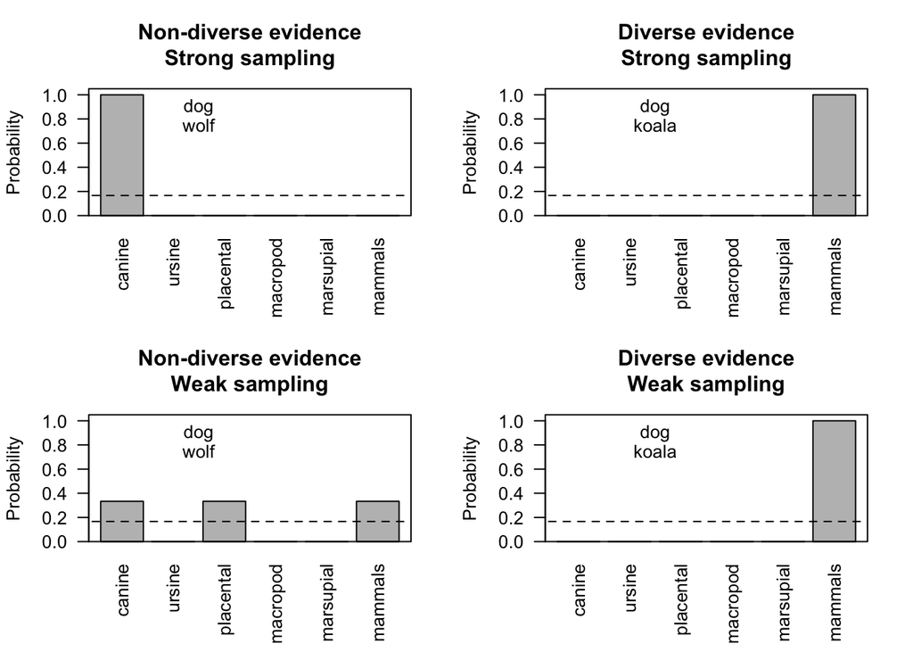

```r
layout(matrix(1:4,2,2))
draw_posterior(posterior_ns, nondiverse, "Non-diverse evidence\nStrong sampling")
draw_posterior(posterior_nw, nondiverse, "Non-diverse evidence\nWeak sampling")
draw_posterior(posterior_ds, diverse, "Diverse evidence\nStrong sampling")
draw_posterior(posterior_dw, diverse, "Diverse evidence\nWeak sampling")
```

```r
layout(1)
```